# Practical Machine Learning Course Project

Melody Premaillon

5 décembre 2017

# Instructions

The goal of your project is to predict the manner in which they did the exercise. This is the “classe” variable in the training set. You may use any of the other variables to predict with. You should create a report describing how you built your model, how you used cross validation,what you think the expected out of sample error is, and why you made the choices you did.You will also use your prediction model to predict 20 different test cases.

# Creation of a validation set and a training set

The given training set was split into two parts to create a training and a validation test set.

```r
partition <- createDataPartition(dataset$classe, p=0.8, list=F)
training <- dataset[partition,]
validation <- dataset[-partition,]
```

# Variable exploration

### Missing values

The dataset has 160 variables. A first step is looking for some missing values. It appears that for 100 variables 15369 values (~98%) are missing (they are equal to NA or ""). This variables are removed from the analysis.

The 7 first column were also removed because it correspond to the experimental condition: hour, number of the exercice, name of theparticipant. All of this fields correspond to experimental conditions and are biased. They do not correspond to real life conditions and cannot be used as predictors.

```
##  [1] "roll_belt"            "pitch_belt"           "yaw_belt"
##  [4] "total_accel_belt"     "gyros_belt_x"         "gyros_belt_y"
##  [7] "gyros_belt_z"         "accel_belt_x"         "accel_belt_y"
## [10] "accel_belt_z"         "magnet_belt_x"        "magnet_belt_y"
## [13] "magnet_belt_z"        "roll_arm"             "pitch_arm"
## [16] "yaw_arm"              "total_accel_arm"      "gyros_arm_x"
## [19] "gyros_arm_y"          "gyros_arm_z"          "accel_arm_x"
## [22] "accel_arm_y"          "accel_arm_z"          "magnet_arm_x"
## [25] "magnet_arm_y"         "magnet_arm_z"         "roll_dumbbell"
## [28] "pitch_dumbbell"       "yaw_dumbbell"         "total_accel_dumbbell"
## [31] "gyros_dumbbell_x"     "gyros_dumbbell_y"     "gyros_dumbbell_z"
## [34] "accel_dumbbell_x"     "accel_dumbbell_y"     "accel_dumbbell_z"
## [37] "magnet_dumbbell_x"    "magnet_dumbbell_y"    "magnet_dumbbell_z"
## [40] "roll_forearm"         "pitch_forearm"        "yaw_forearm"
## [43] "total_accel_forearm"  "gyros_forearm_x"      "gyros_forearm_y"
## [46] "gyros_forearm_z"      "accel_forearm_x"      "accel_forearm_y"
## [49] "accel_forearm_z"      "magnet_forearm_x"     "magnet_forearm_y"
## [52] "magnet_forearm_z"
```

### Exploratory analysis

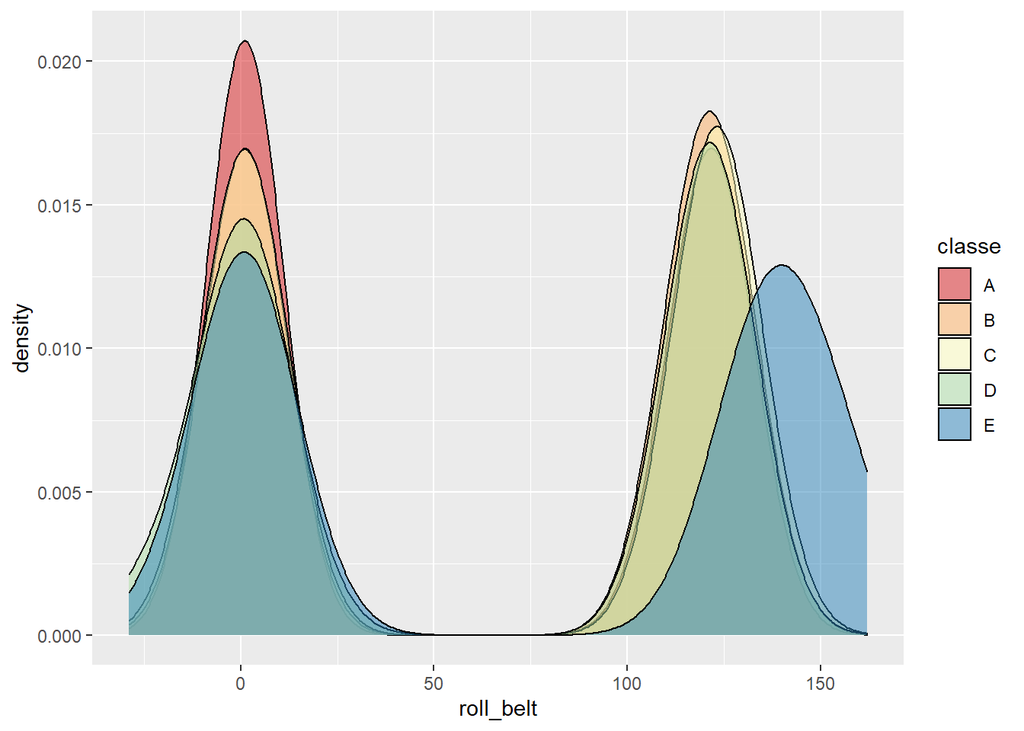

# Machine learning algorithm

A random forest analysis was performed on this dataset. This choice was made because of (i) efficiency of this algorithm; (ii) it allows to predict classes (iii) it allows continuous and categorial variables.

### Data splitting, creation of 10 folds

The dataset was split into 10 folds to use cross-validation in the tranining set.

```r
set.seed(4564)
myfolds <- createFolds(training$classe, k=10, list=F, returnTrain = F)
```

### Random forest application with default parameters, comparison to a simple tree model

Random forest algorithm was applied and tested on each of the ten folds within the training set. The median accuracy is of 0.99554 wich is extremly precise. In comparison, the same process was applied with a single regression tree and the median accuracy was of 0.4901211

```r
tapply(eval$accuracy, eval$meth, median)
```

```
##     1tree RFdefault
## 0.4901211 0.9955400
```

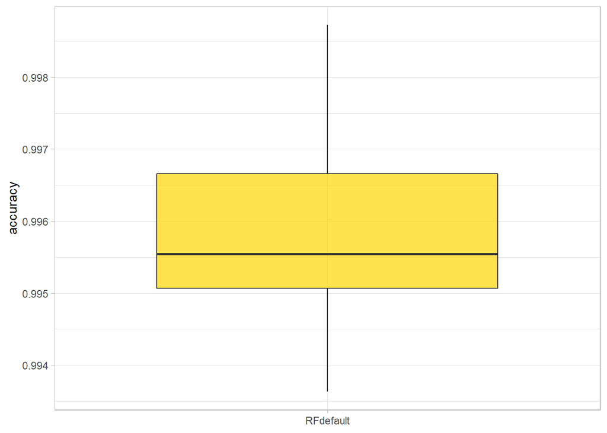

### Expected out of sample error

As the accuracy is good on training set with random forest default parameters (ntree=500, mtry =7), the choice was made not to tune the model and evaluate it on the evaluation set to have an idea of what could be out of sample error.

```r
modFitRF <- randomForest(classe~. , training)
predRF <- predict(modFitRF, validation)
confusionMatrix(predRF, validation$classe)$overall
```

```
##       Accuracy          Kappa  AccuracyLower  AccuracyUpper   AccuracyNull
##      0.9956666      0.9945184      0.9930708      0.9974737      0.2844762
## AccuracyPValue  McnemarPValue
##      0.0000000            NaN
```

Estimation on what could be out of sample error are really good whith an accuracy and a kappa > 0.99. The confusion matrix on validation set gives:

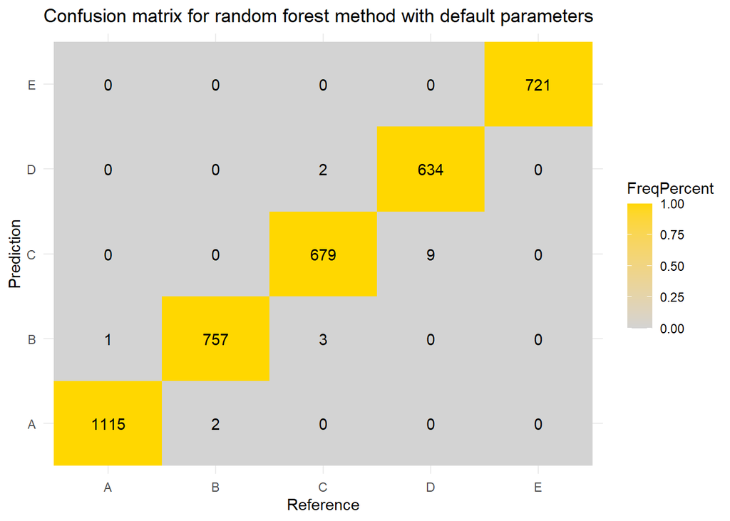

# Application of the model to test set

As the out of sample error is really good on the evaluation test, the random forest algorithm was applied to the test set wich correspond to 20 different case.

```r
  predfinalRF <- predict(modFitRF, testing[,-53])
  predfinalRF <- data.frame(problem_id=testing[,53], classe_prediction = predfinalRF)
  predfinalRF
```

```
##    problem_id classe_prediction
## 1           1                 B
## 2           2                 A
## 3           3                 B
## 4           4                 A
## 5           5                 A
## 6           6                 E
## 7           7                 D
## 8           8                 B
## 9           9                 A
## 10         10                 A
## 11         11                 B
## 12         12                 C
## 13         13                 B
## 14         14                 A
## 15         15                 E
## 16         16                 E
## 17         17                 A
## 18         18                 B
## 19         19                 B
## 20         20                 B
```

```r
  table(predfinalRF$classe_prediction)
```

```
##
## A B C D E
## 7 8 1 1 3
```

The final model predict that exercice is well done in seven case over 20.